# scRNASeq workflow - Vignette

### Graph-based methods

#### MCL

The MCL algorithm is short for the Markov Cluster Algorithm. It is an unsupervised cluster algorithm for graphs based on simulation of (stochastic) flow in graphs ([van Dongen et. al](https://micans.org/mcl/)).

As a first step, we will construct an adjacency matrix from a similarity matrix using the function `build_adjacency_matrix`. This function takes as input either a pre-computed similarity matrix or the raw counts from which to calculate a correlation matrix. In addition, it requires a value for the similarity cutoff. It then builds a binary matrix of 1s and 0s form this information. A 1 means the similarity was larger than the cutoff. We can set the cutoff to “auto”, this way, the algorithm will look for a valley in the distribution of similarities and use this as a cutoff. The function returns a list with the following entries:

- adj: The adjacency matrix
- cor: The similarity matrix
- cutoff: The similarity cutoff

We will use the 1 - the relative euclidean distance in PCA space as our similarity measure:

```r
sim = 1-as.matrix(dist_eucl)/max(dist_eucl)
adj_corr = build_adjacency_matrix(mat = sim,cutoff="auto",is_similarity=T)
```

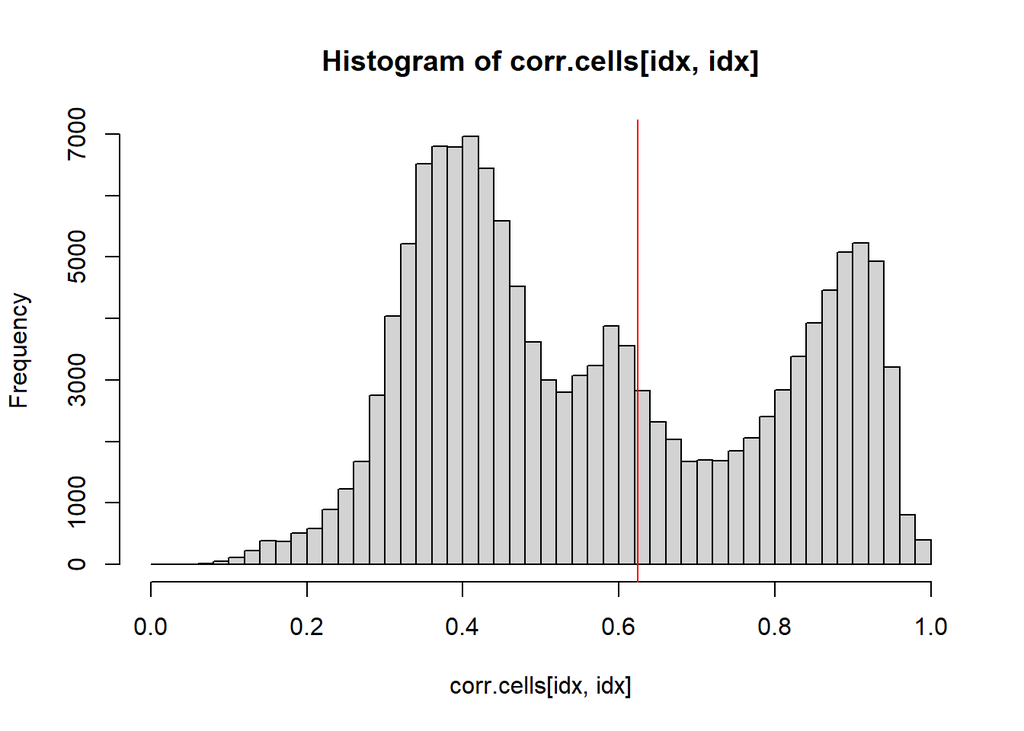

Now we run MCL with the above list as input:

```r
# use R MCL:
groups_MCL = MCLcell.clust(adj_corr, use_external_mcl = FALSE)
#use external MCL (UNIX only)
#groups_MCL = MCLcell.clust(adj_corr, use_external_mcl = TRUE, mcl_path = mcl_path)
sce_info$MCL = as.factor(groups_MCL)
table(sce_info$MCL,sce_info$hclust_eucl)
```

```
##
##     CD4 T-cell CD14++/CD16- Monocyte B-cell CD8 T-cell NK cell
##   1          0                     0      0          1      18
##   2          0                    90      0          0       0
##   3        158                     0     52         36       0
##
##     CD14+/CD16++ Monocyte Dendritic cell
##   1                     0              0
##   2                    10              6
##   3                     0              0
```

We see that the MCL found only three clusters, merging the B and T cells:

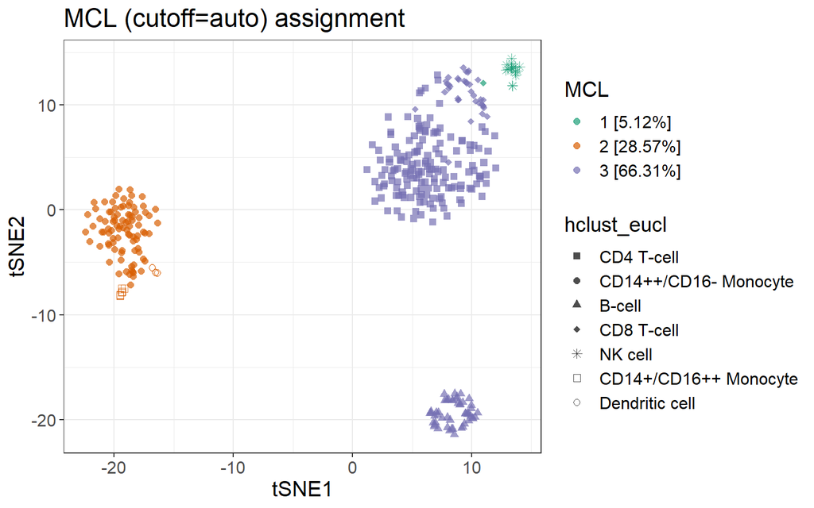

```r
p = my_plot_tSNE(tsne = tsne_info, color = colData(sce_info)[,"MCL",drop=F],
                 shape = colData(sce_info)[,"hclust_eucl",drop=F],
                 title = "MCL (cutoff=auto) assignment",
                 show_proportions = T)
print(p)
```

We can try changing the cutoff for the calculation of the adjacency matrix and re-run the algorithm:

```r
adj_corr = build_adjacency_matrix(mat = sim,cutoff=0.8,is_similarity=T)
```

```
## Building the adjacency matrix
```

```r
groups_MCL = MCLcell.clust(adj_corr,mcl_path = mcl_path)
```

```
## Building Graph
```

```r
sce_info$MCL2 = as.factor(groups_MCL)
table(sce_info$MCL2,sce_info$hclust_eucl)
```

```
##
##      CD4 T-cell CD14++/CD16- Monocyte B-cell CD8 T-cell NK cell
##   1           0                     0     52          0       0
##   3         155                     0      0          4       0
##   5           0                    89      0          0       0
##   6           3                     0      0         32       0
##   10          0                     0      0          1      18
##   14          0                     0      0          0       0
##   16          0                     1      0          0       0
##
##      CD14+/CD16++ Monocyte Dendritic cell
##   1                      0              0
##   3                      0              0
##   5                      0              0
##   6                      0              0
##   10                     0              0
##   14                    10              0
##   16                     0              6
```

```r
p = my_plot_tSNE(tsne = tsne_info, color = colData(sce_info)[,"MCL2",drop=F],
                 shape = colData(sce_info)[,"hclust_eucl",drop=F],
                 title = "MCL (cutoff=0.8) assignment",
                 show_proportions = T)
p = p + scale_color_manual(values = brewer.pal(10,"Paired"))
```

[output not shown]

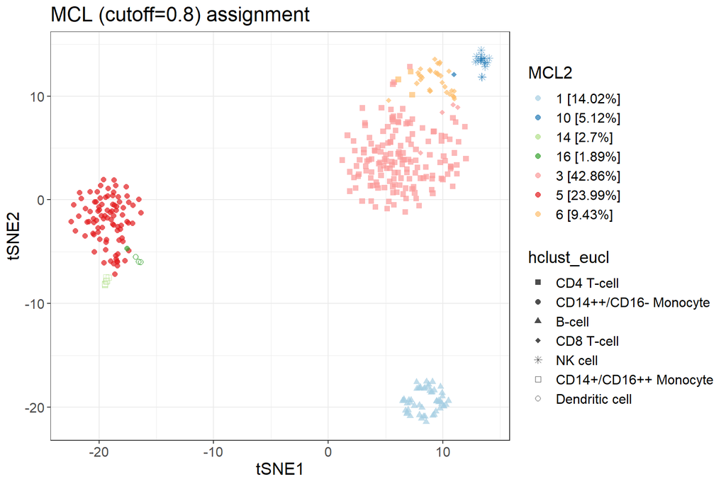

```r
print(p)
```

We note that by raising the similarity cutoff, we can force MCL to make more clusters. We now find the expected populations.

In conclusion, MCL performs similar to hierearchical clustering. Its main advantage is that it is much faster than hclust and can therefore be used on datasets with ten thousands of cells. The main drawback is that MCL is very sensitive to the provided input. Using a similarity measure that does not appropriately separate cells or using the wrong similarity cutoff will lead to MCL making lots of clusters with just one cell inside. The automated cutoff determination should provide some guidance here, but it is not guaranteed to work in all cases.

### Density clustering (DBSCAN)

DBSCAN is a density clustering algorithm that is based on a k-nearest neighbor search. In a nutshell, it identifies clusters as regions in space that contain many points with shared neighbors. DBSCAN works best in a lower dimensional space, so we weill again use the coordinates in PCA space as input. The `run_dbscan` function requires the following inputs:

```r
DBSCAN_groups = run_dbscan(dist_eucl,eps="auto",min_pts=7,tol=0.02)
```

```
## [1] "Epsilon:  3.62000511415425"
```

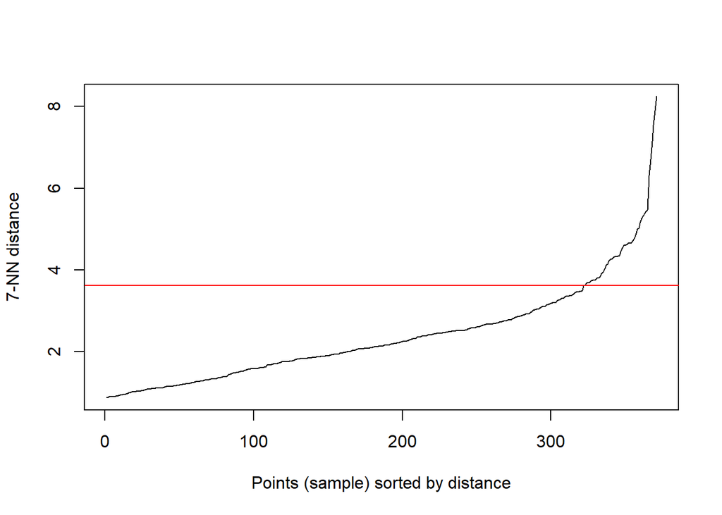

Visualize the assignment:

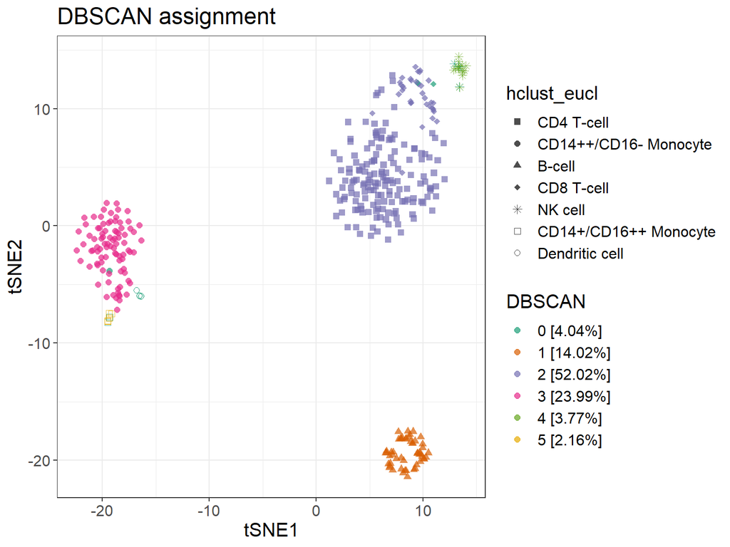

```r
sce_info$DBSCAN = as.factor(DBSCAN_groups)
p = my_plot_tSNE(tsne = tsne_info, color = colData(sce_info)[,"DBSCAN",drop=F],
                 shape = colData(sce_info)[,"hclust_eucl",drop=F],
                 title = "DBSCAN assignment",show_proportions = T)
print(p)
```

We see that DBSCAN correctly identified the clearly separated clusters, but failed for the more continuous ones. This illustrates the main disadvantage of this algorithm: It can only find clusters that have no density between them. On the bright side, it is really fast and it does not require any assumptions of the cluster shape or size.

Save the SCESet that now contains all the assignments:

```r
save(sce_info,file = file.path(out_data_dir,"sce_info.RData"))
```

## Differential expression analysis

The workflow contains wrapper functions for running differential expression analysis using several widely-used packages. For a comparison of methods, consider the recent study by Soneson and Robinson, which can be found [here](https://doi.org/10.1101/143289).

The main findings of the study are that methods differ in the number and characteristics of the genes they report as differentially expressed in a manner that is dependent on the respective dataset. Performance of the methods overall was found to be similar across methods, with those developed for bulk data not being significantly worse than those specifically designed for single-cell data.

If we are interested in finding a small number of high-confidence marker genes, it might be most useful to run several methods and check what their overlap is. In general, I found the methods to be fairly consistent, especially for high expressed genes. For low expressed genes, results from any analysis should be taken with a grain of salt because of the very high underlying technical variability. Special care should be taken when comparing cell types that differ in size and/or RNA content and therefore have cell-specific dropout rates, in which case most low expressed genes are only detected in the large cells.

Currently, wrappers to one non-parametric test (Wilcoxon/Mann-Whitney) and two methods based on linear models (limma, MAST) are provided.

Every wrapper function takes the same four variables as input:

- sce: the full SCESet after QC and normalization
- cl_id: The name of the grouping that should be used. Here, we use the assignment obtained from hiererchical clustering on distances in PCA space, which we called “hclust_eucl”.
- cl_ref: Which cluster we want to compare against all the others. We select “B-cell”. Note: If you wish to do a direct comparison between two clusters, you can do so by setting all assignments but the two you want to compare to `NA`, which for factors is very convenient using `droplevels()`.
- fc_cutoff and alpha: The cutoffs for fold changes and p-values used to determine whether a gene is significantly DE. Note that your cutoffs have no effect on the analysis, and because the results for all genes are returned, you can still change the cutoffs afterwards.

Before we can start, we need to add some of the cluster assignments we obtained in the previous section to the SCESet that contains all genes:

```r
sce_clean$SC3_assignment = sce_info$SC3_assignment
sce_clean$hclust_eucl = sce_info$hclust_eucl
```

### Wilcoxon test

We can run the Wilcoxon test using the `run_wilcoxon_test` wrapper function. This will take as input the above specified variables and return a `data.table` containing (adjusted) p-values and fold changes per gene.

NOTE: The `pseudocount` parameter is deprecated and will be removed!

```r
de_wilcox = run_wilcoxon_test(sce_clean, cl_id = "hclust_eucl", cl_ref = "B-cell",
                           fc_cutoff = 1, alpha = 0.05)
dim(de_wilcox)
```

```
## [1] 5059    5
```

```r
head(de_wilcox)
```

```
##            gene_id       pval      log2fc  adj_pval DE_flag
## 1: ENSG00000279457 0.45794045  0.05675714 0.7003732   FALSE
## 2: ENSG00000188976 0.14517571 -0.05789450 0.3797538   FALSE
## 3: ENSG00000188290 0.06415560 -0.07157740 0.2382990   FALSE
## 4: ENSG00000187608 0.18583086 -0.12223695 0.4282999   FALSE
## 5: ENSG00000186891 0.26788661  0.02994900 0.5279464   FALSE
## 6: ENSG00000186827 0.07159853 -0.05737828 0.2541873   FALSE
```

We see that the function returned a `data.table` containing all gene IDs plus the test statistics and estimated fold changes for each of them. We can use the DE_flag entry to check how many genes were found to be significantly DE (i.e. adjusted p-value < 0.05 and absolute log2 fold change > 1).

```r
table(de_wilcox$DE_flag)
```

```
##
## FALSE  TRUE
##  5022    37
```

A useful way to check whether the method was biased towards calling genes in a specific expression range DE is to plot log2 fold changes v.s. the mean expression of a gene. We will add the mean_exprs column in the feature metadata to the `de_wilcox` table by using `merge` from the `data.table` package:

```r
mean_exprs_dt = data.table(gene_id = rownames(sce_clean),mean_exprs = rowMeans(norm_exprs(sce_clean)))
de_wilcox = merge(de_wilcox,mean_exprs_dt, by = "gene_id")
names(de_wilcox)
```

```
## [1] "gene_id"    "pval"       "log2fc"     "adj_pval"   "DE_flag"
## [6] "mean_exprs"
```

We note that the mean_exprs column has been added to `de_wilcox`. Now we make a plot by calling `generic_scatterplot`. This function takes a `data.table` as input and makes a scatterplot of two columns, x_col and y_col, against each other. Optional column names can be provided to control color, shape and size of the points. The function returns a `ggplot` object, to which we can easily add other features, for example, a title:

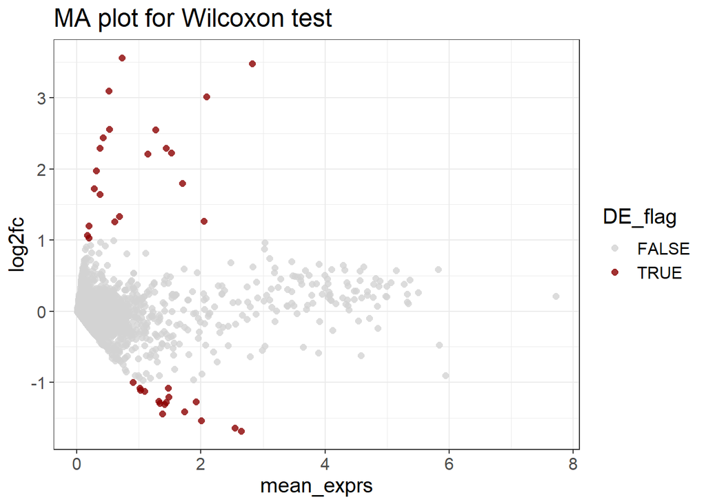

```r
p = generic_scatterplot(de_wilcox, x_col = "mean_exprs", y_col = "log2fc",
                        color = "DE_flag")
print(p+ggtitle('MA plot for Wilcoxon test'))
```

We see that because fold changes are estimated as the difference in log2 mean expression rather than a ratio, very low expressed genes have fold changes around zero.

To make a volcano plot, we can again use `generic_scatterplot`:

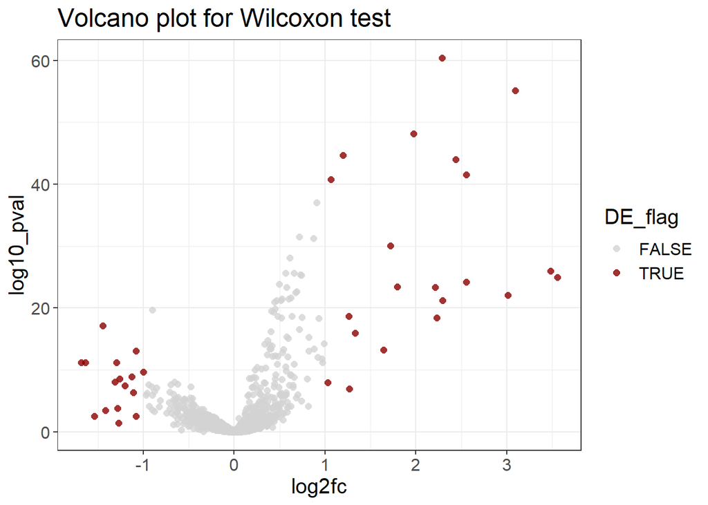

```r
de_wilcox[,log10_pval:=-log10(adj_pval)]
p = generic_scatterplot(de_wilcox, x_col = "log2fc", y_col = "log10_pval",
                        color = "DE_flag")
print(p+ggtitle('Volcano plot for Wilcoxon test'))
```

Note: In general, the more cells you have, the more tiny changes will become significant. The `DE_flag` parameter is therfore controlled mostly by your fold change cutoff, unless you set a very stringent p-value cutoff (~10^-20). It is probably best to use the fold change / p-value combination more as a way of ranking genes than as an absolute threshold and focus on the genes that come out on top.

Now let’s check whether the identified genes make sense:

```r
library(DT)
top_DE = de_wilcox[DE_flag==TRUE][order(log2fc,decreasing = T)]$gene_id[1:20]
gene_table = get_gene_annotations(top_DE,get_descriptions = T)
datatable(gene_table, caption = "Top 20 upregulated genes in B-cells")
```

|  | gene_id | chr | symbol | gene_biotype | eg | description |
| --- | --- | --- | --- | --- | --- | --- |
| 1 | ENSG00000007312 | 17 | CD79B | protein_coding | 974 | CD79b molecule |
| 2 | ENSG00000019582 | 5 | CD74 | protein_coding | 972 | CD74 molecule |
| 3 | ENSG00000100721 | 14 | TCL1A | protein_coding | 8115 | TCL1 family AKT coactivator A |
| 4 | ENSG00000104894 | 19 | CD37 | protein_coding | 951 | CD37 molecule |
| 5 | ENSG00000105369 | 19 | CD79A | protein_coding | 973 | CD79a molecule |
| 6 | ENSG00000153064 | 4 | BANK1 | protein_coding | 55024 | B cell scaffold protein with ankyrin repeats 1 |
| 7 | ENSG00000156738 | 11 | MS4A1 | protein_coding | 931 | membrane spanning 4-domains A1 |
| 8 | ENSG00000179344 | 6 | HLA-DQB1 | protein_coding | 3119 | major histocompatibility complex, class II, DQ beta 1 |
| 9 | ENSG00000196126 | 6 | HLA-DRB1 | protein_coding | 3123 | major histocompatibility complex, class II, DR beta 1 |
| 10 | ENSG00000196735 | 6 | HLA-DQA1 | protein_coding | 3117 | major histocompatibility complex, class II, DQ alpha 1 |

[output cut: 10 more lines]

And we are happy to see that the top upregulated genes correspond to known B-cell markers such as CD79 or MHCII subunits.

### limma

The function `run_limma` is used for both methods. In addition to the standard input described above, we need to provide the following inputs:

- method: which limma method we want to use. Trend is more stable than voom.
- count_thr, pct: Threshold for gene filtering. Genes that do not have a minimum of `count_thr` counts in at least `pct` percent of cells in at least one cluster will be ignored. For this extremely sparse data, we set this to 1.

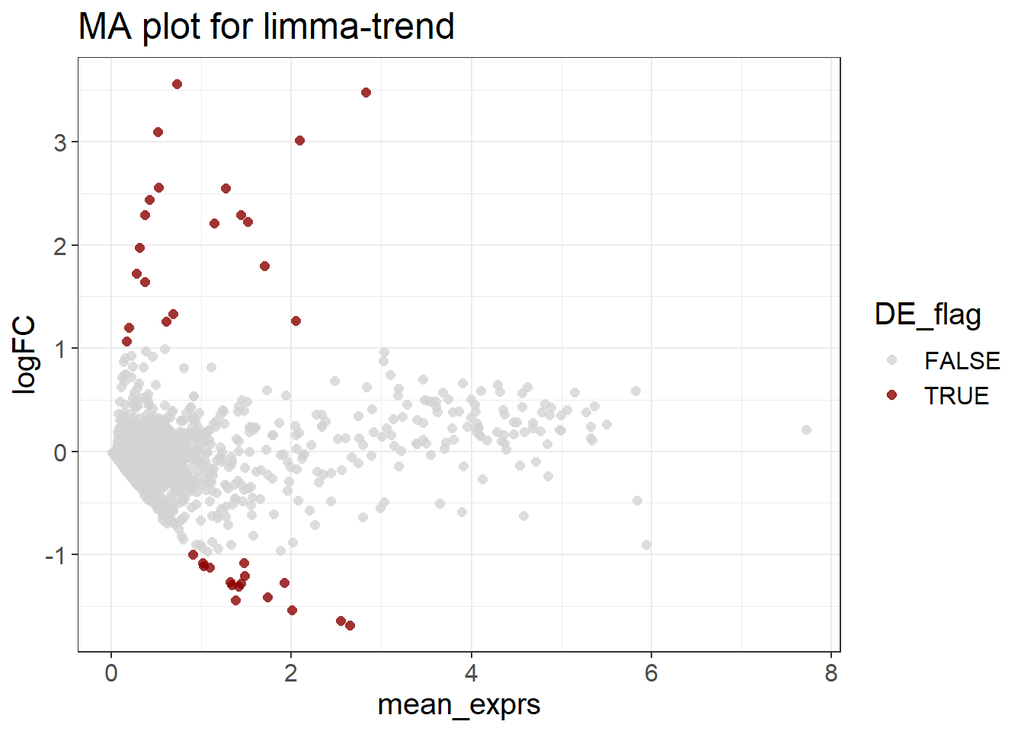

```r
de_limma_trend = run_limma(sce_clean, cl_id = "hclust_eucl", cl_ref = "B-cell",
                          method = "trend", fc_cutoff = 1, alpha = 0.05, count_thr = 1, pct=50)

de_limma_trend = merge(de_limma_trend, mean_exprs_dt)

p = generic_scatterplot(de_limma_trend, x_col = "mean_exprs", y_col = "logFC",
                        color = "DE_flag")
print(p + ggtitle("MA plot for limma-trend"))
```

### Using SC3 to find markers

This sections shows how to tweak the `sc3_calc_biology` function to work with any arbitrary clustering.

```r
library(SC3)

# add the slots the calc biology function checks
dummy = list(`0`=0)
sce_clean@metadata$sc3$consensus = dummy
sce_clean@metadata$sc3$n_cores = 4
rowData(sce_clean)$sc3_gene_filter = rep(TRUE,dim(sce_clean)[1]) #do not filter out any genes
rowData(sce_clean)$feature_symbol = rowData(sce_clean)$symbol

# add whatever clustering assignment you want to the sc3_0_clusters slot
sce_clean$sc3_0_clusters = as.factor(sce_info$cell_type)

sce_clean = sc3_calc_biology(sce_clean, k = 0)
```

Plot markers:

```r
# change the plotted gene names to symbol for better readability
plot_sce = sce_clean[!is.na(rowData(sce_clean)$symbol),]
rownames(plot_sce) = rowData(plot_sce)$symbol
custom_sc3_plot_markers(plot_sce, k=0, p.val = 0.01, auroc = 0.90, show_pdata='sc3_0_clusters')
```

[output not shown]

## Functions

This section lists all custom functions that are part of the workflow. These are equivalent to everything that is provided in the ./code directory, therefore this section is merely for documentation purposes.

### Setup

#### library_calls()

The function *library_calls()* calls all the libraries that are required throughout the workflow. Additional packages are loaded whenever needed. The reason for this is that some of the newer bioconductor packages load a million dependencies, and currently, R has a limit on how many packages can be loaded at any time.

#### get_gene_annotation()

This is the default function to annotate genes. It uses the ensembldb and EnsDb.Hsapiens.v79 packages. Ensembldb is preferred over biomaRt because it is much faster and it uses a specific annotation package, making it more reproducible. Optionally, gene descriptions in human-readable form are obtained from org.Hs.eg.db.

Input:

- gene_list = a list of ensembl gene IDs as a character vector
- get_descriptions = should descriptions be obtained from org.Hs.eg.db/org.Mm.eg.db? TRUE or FALSE. Note that this is slow for a long gene list.
- v = verbose flag. If set to true, prints all the errors that my_get() catches. Should be set to true only for debugging purposes.
- organism: one of either “mouse” or “human”

Output:

- geneName = a data.table of gene annotations. Note that this table is sorted by gene identifier.

#### get_gene_annotations_biomart()

Gene annotations can also be retrieved from biomaRt, however, ensembldb is preferred for the above mentioned reasons.

### Quality control

#### Filtering of genes and cells

The functions below are used for manual filtering of cells and genes based on several QC metrics.

Input:

- counts: Matrix of raw counts.
- n_th: A single number specifying the cutoff for the respective filter. In the gene filter, this is the minimal number of cells with counts above `min_counts`. In the feature_counts and n_UMI filters, this is the minimal number of total counts or total UMIs, respectively, per cell.
- min_counts: In the gene filter, this specifies the minimum number of counts. The filter removes genes that do not have at least `min_counts` counts in at least `n_th` cells.
- mt_genes.amount: a vector containing the percentage of mitochondrial genes per cell. This information is stored in sce$percent_feature_controls_MT.
- t: a single number specifying the maximum percentage of reads mapped to mitochondrial genes.

#### Visualizing the manual filters

Input:

- sce, input_sce: an SCESet from which the things to plot are taken
- min_genes, min_UMI, t: the cutoffs selected for minimum number of genes per cell [log2], minimum number of UMIs per cell [log2], and maximum percentage of mitochondrial genes

#### Cell cycle assignment

Using the cyclone function from scran:

```r
annotate_cell_cycle = function(sce, organism = "human", gene.names = rownames(sce)){
  if(organism == "human"){
    hs.pairs = readRDS(system.file("exdata", "human_cycle_markers.rds", package="scran"))
    assigned = cyclone(sce, pairs=hs.pairs, gene.names = gene.names)} else if (organism == "mouse"){
      mm.pairs = readRDS(system.file("exdata", "mouse_cycle_markers.rds", package="scran"))
      assigned = cyclone(sce, pairs=mm.pairs, gene.names = gene.names)
    } else {stop("Organism has to be human or mouse.")}

  return(assigned)
}
```

### Normalization

All available normalizations are collapsed in a single function `normalize_counts` for convenience.

Input:

- sce: SCESet. Contains all your data.
- method: Character. The method you want to use to normalize. Choices are:
  - TC = total count normalization (multiply this by 10^6 to get CPMs)
  - UQ = upperquartile
  - RLE = relative log-expression, as in DESeq2
  - TMM = trimmed mean of M-values, as in edgeR
  - scran (default) = Lun sum factors, implemented in scran package

Output:

- an SCESet with the normalized expression values in the exprs and norm_exprs slots

### Feature selection

#### Highly variable genes (Brennecke et. al, 2013)

This method implements the approach presented by Brennecke et. al, NMeth, 2013 ([here](http://www.nature.com/nmeth/journal/v10/n11/full/nmeth.2645.html?foxtrotcallback=true)).

Input:

- x: a matrix of normalized counts, NOT on log scale. Note that therefore you will need to provide 2^norm_exprs(SCESet)-1 if your input comes from an SCESet.
- PLOT: logical. Should a plot be printed?
- qcv: Between 0 and 1. Threshold for the coefficient of variation (see below).
- q: Between 0 and 1. The q-th quantile of the mean expression of all genes having a CV > qcv is used as a threshold. Genes having mean below this threshold are not included in the analysis.
- pv: the p-value cutoff
- minBiolDisp: Between 0 and 1. The CV of the underlying biological variation. Leave at default unless you have a good reason to change it.

Output:

- info: a vector of logicals specifying whther a gene is informative or not.

#### Using depth-adjusted negative binomial model (M3Drop)

This method is implemented in M3drop versions > 2.0. It models the gene counts as a negative binomial with a depth-adjusted mean. Gene-specific dispersions are then fit to the sample variance. A detailed description of the method can be found [here](https://www.biorxiv.org/content/early/2016/10/20/065094). Based on the calculated model, informative genes can be selcted by comparing expected values for dropouts (NBDrop) or dispersions (NBDisp) to the predicted ones.

The function *run_DANB* is used for both methods.

Input:

- counts: a matrix of RAW counts
- save_plot: logical. Should the produced plot be saved?
- method: One of either “NBDrop” or “NBDisp”. The method used for feature selection.
- cutoff: The p-value cutoff for NBDrop or the percentage of genes returned by NBDisp.
- perc_genes: The percentage of genes to keep (can only be provided instead of cutoff)

Output:

- info: a vector of logicals specifying whther a gene is informative or not.

#### Select genes based on GO annotation

Input:

- go_id: A GO identifier
- organism: One of either “human” or “mouse”

Output:

- gene_ens: a list of ensembl gene identifiers mapping to this GO term.

### Clustering

#### MCL (adapted from code provided by Marilisa Neri)

Input:

- mat: a matrix of normalized expression values on a log2 scale or a matrix of similarities if is_similarity = TRUE
- cutoff: Either “auto” or a number between 0 and 1. Parameter for the correlation cutoff used to contruct the adjacency matrix. If set to “auto”, the function will attempt to find a valley in the distribution of similarities and use this as a cutoff. If a number is provided, it will use this as a cutoff.
- adj: List. The output of *build_adjacency_matrix*, a list containing the adjacency matrix, the similarity matrix and the chosen cutoff.

Output:

- groups.MCL: The cluster assignments. “0” means the cell was not assigned to any cluster.

#### DBSCAN

DBSCAN is a density based algorithm that identifies clusters as regions of high density that are separated by regions of low density. Note that it is not suited for very high-dimensional data, therefore should be used only in combination with dimensionality reduction (usually PCA).

Input:

- dist: A dist object containing cell-cell distances in low-dimensional space.
- min_pts: Integer. The number minimum points in the eps neighborhood. Generally, this should be one more than the dimensionality of the space in which distances were calculated, i.e. the number of used principal components +1.
- eps: “auto” or a number. The radius of the eps neighborhood (see dbscan documentation for details). As a rule of thumb, this should be the y value of the “elbow” on the KNNdistplot. If set to “auto”, eps will be determined automatically.
- tol: The tolerance when determining eps. The default is 0.01, which in general works quite well. The lower the tolerance, the smaller eps.

### Differential Expression Analysis

The functions in the following are wrappers to the respective packages. for details what each of them does, please refer to the package documenatations.

General input for all of them:

- sce = the SCESet after QC or after normalization
- cl_id : the name of the grouping (e.g. “mclust”) used in the comparison. Must be a column name of colData(sce)
- cl_ref: the entry in colData(sce)$cl_id that should be used as the reference, i.e. against which all the rest of the cells are compared
- alpha = false discovery rate cutoff, default = 0.05
- fc_cutoff = log2 fold change cutoff, default = 0.5

#### Wilcoxon test

This function runs the Wilcoxon test to calculate p-values, adjusts them for multiple correction using Benjamini-Hochberg method, and calculates fold changes. There is one additional parameter:

- pseudocount: Deprecated and will be removed!

#### limma

This function implements the limma-voom and limma-trend methods. It takes three additional parameters:

- count_thr, pct: Filter criteria. Genes that do not have a minimum count of `count_thr` in `pct`% of cells in at least one cluster are excluded. This is required because limma can become unreliable in the presence of too many very low expressed genes.
- method: one of “voom” or “trend”. Specifies which limma method to use. The default is “trend” since this seems to work better with zero-inflated data.

### Miscellaneous Plotting

#### Generic scatterplot using ggplot2 and data.table

This function takes a data.table as input and plots two columns, x_col and y_col, against each other. Optional arguments can be provided to control color, size and shape of the plotted symbols.

Input:

- dt: data.table with all the data to be plotted
- x_col: name of the column to lot on x axis
- y_col: name of column to plot on y axis
- color: name of column to use as color values. If numeric, a continuous color scheme will be applied, if character or factor, colors will be discrete.
- shape: name of column to use for shape
- size: name of column to use for size
- alpha: transparency
- abs_size; If no values for size are provided, abs_size sets the absolute size of the points on the plot.

Output:

- p: The plot as a ggplot object

#### PCA plot

Calculates a PCA and makes a plot.

Input:

- counts: A matrix of log2 transformed, raw or normalized counts. If no counts are provided, a pre-computed prcomp object has to be provided instead.
- pca: prcomp object. A result from a previous PCA calculation. If missing, a new PCA is calculated.
- scale_pca: Logical. Should the data be scaled to have unit variance? Default = TRUE.
- center_pca: Logical. Should the data be centered before calculating PCA? Default = TRUE.
- comp: Numerical vector with 2 elements. The 2 components to plot against each other.
- return_pca: Logical. Should the prcomp object be returned? If TRUE, the function returns a list with pca = the prcomp object and plot = the plot. If false, only the plot is returned as a ggplot2 object.
- use_irlba: Logical. Should the principal components be calculated using prcomp_irlba? Using irlba ignificantly increases speed for large datasets.
- color, size and shape: Each a data.frame with one column containing the respective values to plot. For colors, numeric values are plotted on a continuous scale, factors as discrete colors. Note that the rownames of the data.frame have to be the same as the rownames of pca, but can be in any order. By default, the column name is used as a label for the color legend. The easiest way of setting any of those values is to use columns in the phenoData of your SCESet, e.g. colors = colData(sce)[,“cluster”,drop=F].
- alpha: Between 0 and 1. Transparency of the points.
- tite: Title of the plot.

#### tSNE plot

Pretty much the same as the PCA plot function, but makes a tSNE map instead.

Input:

- counts: A matrix of log2 transformed, raw or normalized counts or a distance matrix. If a distance is used, is_distance has to be set to TRUE. If no values are provided, a pre-computed Rtsne object has to be provided instead.
- tsne: Rtsne object. A result from a previous tSNE calculation. If missing, a new tSNE is calculated.
- return_tsne: Logical. Should the Rtsne object be returned? If TRUE, the function returns a list with tsne = the Rtsne object and plot = the plot. If false, only the plot is returned as a ggplot2 object.
- is_distance: Logical. Is the input for Rtsne a distance matrix?
- scale_pca: Logical. Should the data be scaled to have unit variance? Default = FALSE.
- n_comp: Number of principal components used by tSNE.
- color, size and shape: Each a data.frame with one column containing the respective values to plot. For colors, numeric values are plotted on a continuous scale, factors as discrete colors. Note that the rownames of the data.frame have to be the same as the rownames of pca, but can be in any order. By default, the column name is used as a label for the color legend. The easiest way of setting any of those values is to use columns in the phenoData of your SCESet, e.g. colors = colData(sce)[,“cluster”,drop=F].
- alpha: Between 0 and 1. Transparency of the plotted points.
- tite: Title of the plot.
- show_proportions: Logical. if the plot is colored by a dsicrete variable, should the proprtions of points per color be shown in the legend?